# Vallino

## Vallino Model

This is a small metabolic network model. here, you can see the flux balance analysis of that model step by step.

Firstly, you need some R packages and install them.

## Install packages and call from libraries

```r
#note: if you use echo=FALSE, you wont see the code.
# install.packages("sybil")
# install.packages("sybilSBML")
# #install sybilGUROBI zip
# #gurobi requires licence
# install.packages("c:/gurobi903/win64/R/gurobi_9.0-3.zip", repos = NULL)
# install.packages("slam", repos = "https://cloud.r-project.org")
library(gurobi)
library(sybil)
library(sybilSBML)
library(sybilGUROBI)
```

## Reading or Loading the model

There are two ways to import metabolic model to R. First way which is in case 1: users can read models from xml file by using readSBMLmod of COBRA Toolbox if the xml file is compatible. Second way which is in case 2: users can import metabolic model by loading RData file of model to R.

```r
prefer = as.integer(readline(prompt="Would you prefer to read sbml formatted model or load mat formatted model? (enter 1 for reading or 2 for load): "))
```

```r
if(prefer ==1){
  Vallino <- readSBMLmod("Vallino_COBRAtc.xml",bndCond = FALSE)
} else {
  load("Vallino.RData")
}
```

## Exploring metabolic model

There are three main fields in the metabolic models.

1. **Stoichiometric Matrix (S Matrix)** = It is a two dimensional numeric matrix that represent coefficients in metabolic reactions. Columns and rows represent reactions and metabolites respectively (Figure 1).

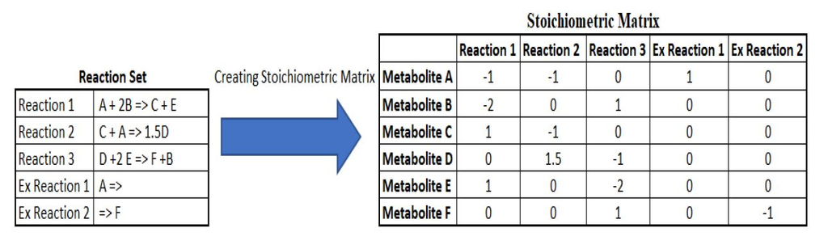

2. **mets** = It is a metabolite list that is included in all reactions. Generally, Abbreviations of metabolites are used.

```r
head(Vallino@met_name)
```

[1] " GLC" " PEP" " GLC6P" " PYR" " ATP" " TREHAL"

3. **rxns** = It is a reaction list.. Generally, Abbreviations of reactions are used.

```r
head(Vallino@react_name)
```

[1] “R1” “R2” “R3” “R4” “R5” “R6”

## Formatting for using gurobi optimizer

There are multiple optimizers that can be used for analyzing metabolic models such as glpk, gurobi and cplex. Unlike gurobi and cplex glpk is a free optimizer. On the other hand gurobi can be used freely by using academic license. Gurobi requires a specific model structure that can be created by using the information inside metabolic model.

Structure of grobi model:

**A =** It is a coeffients of all equations. These equations represent reactions in metabolic modeling, and all coefficients of reactions can be accessible from the S matrix.

**lb=** It indicates lower bound of the reactions. It is used to constrain metabolic model. The minimum allowable rate for the flux of reaction can be defined by using the lb vector.

**ub=** It indicates upper bound of the reactions. It is used to constrain metabolic model. The maximum allowable rate for the flux of reaction can be defined by using the lb vector.

**rhs=** It is abbrevation of right hand side vector. It defines concentration changes of metabolites. All of the values of rhs generally are 0 since Flux Balance Analysis calculates steady-state metabolic fluxes. (Figure 2). It can be accessible from the b vector inside model.

**obj=** it is a objective function vector. It defines which reaction will be maximised or minimised. All of the values except the indices of objective reaction should be 0. The indices of the reactions that are wanted to be maximized should be -1. On the other, 1 means that minimize this reaction.

**sense=** The senses of the linear constraints. It can be used as “=”, “>” or “<”.

**vtype=** It defines the variable types. It can be used as ‘C’ (continuous), ‘B’ (binary), ‘I’ (integer), ‘S’ (semi-continuous), or ‘N’ (semi-integer). “C” should be used since fluxes are continuous values.

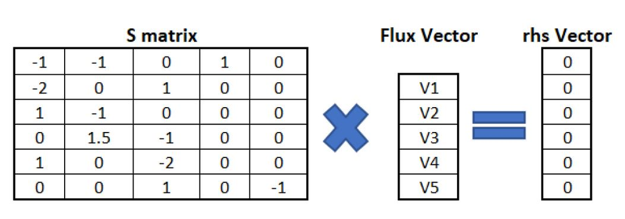

Figure2

## Phase I: constraints

glucose uptake rate = 25.1 NH3 uptake rate= 17.1433 O2 uptake rate= 57.981 trehalose release rate= 1.255*0.5 lactate release= 0.0753